# Tidvyerse Basics

## What else should I know about the tidyverse and tidy data?

In my opinion, the tidyverse is much more than just a set of packages, and tidy data is more than just data structured according to a set of principles. These are underlying constructs of a larger, more abstract **mentality** that emphasizes **readability** and **reproducibility**. These principles are coveted in the realm of data science and analysis.

By **readability**, I’m alluding to the manner in which the tidyverse naturally emphasizes data manipulation and analysis actions with verbs. For example, the [vignette for the dplyr package](https://cran.r-project.org/web/packages/dplyr/vignettes/dplyr.html) describes its implicit implementation of this principle.

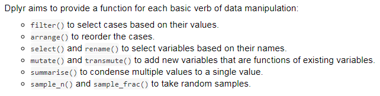

FYI: All of dplyr’s functionality is captured succintly in the “Data Transformation” “cheat sheet” on RStudio’s website. [^6]

[figure not shown]

The readability provided by the verbs in tidyverse functions is complemented/facilitated by the “pipe” operation. “Piping” can easily be done using magrittr’s `%>%` operator with functions in tidyverse packages. The notion of “piping” may not be completely unfamiliar to those accustomed to programming. (For example, the “+=” operator implements “piped” addition in C++.) To those unfamiliar, with piping, it is essentially the composition mathematical function (i.e. `x %>% f(y)` is equivalent to `f(x, y)`).

Combined with good code style, piping can make code self-expanatory. For example, see the following comparison of dplyr operations using the nycflight13 package. [^7]

```r
library("nycflights13")
dim(flights)
flights
```

```
## [1] 336776     19
## # A tibble: 336,776 x 19
##     year month   day dep_time sched_dep_time dep_delay arr_time
##    <int> <int> <int>    <int>          <int>     <dbl>    <int>
##  1  2013     1     1      517            515         2      830
##  2  2013     1     1      533            529         4      850
##  3  2013     1     1      542            540         2      923
##  4  2013     1     1      544            545        -1     1004
##  5  2013     1     1      554            600        -6      812
##  6  2013     1     1      554            558        -4      740
##  7  2013     1     1      555            600        -5      913
##  8  2013     1     1      557            600        -3      709
##  9  2013     1     1      557            600        -3      838
## 10  2013     1     1      558            600        -2      753
## # ... with 336,766 more rows, and 12 more variables: sched_arr_time <int>,
## #   arr_delay <dbl>, carrier <chr>, flight <int>, tailnum <chr>,
## #   origin <chr>, dest <chr>, air_time <dbl>, distance <dbl>, hour <dbl>,
## #   minute <dbl>, time_hour <dttm>
```

Even though the data is tidy and the code uses dplyr functions, the second set of commands using the pipe operator are inarguably easier to interpret because the operations are performed in an ordered fashion (i.e. left-to-right, top-to-bottom). (The first method is less comprehensible because the operations are performed from “inside to out”.)

```r
filter(
  summarise(
    select(
      group_by(flights, year, month, day),
      arr_delay, dep_delay
    ),
    arr = mean(arr_delay, na.rm = TRUE),
    dep = mean(dep_delay, na.rm = TRUE)
  ),
  arr > 30 | dep > 30
)
```

```
## # A tibble: 49 x 5
## # Groups:   year, month [11]
##     year month   day      arr      dep
##    <int> <int> <int>    <dbl>    <dbl>
##  1  2013     1    16 34.24736 24.61287
##  2  2013     1    31 32.60285 28.65836
##  3  2013     2    11 36.29009 39.07360
##  4  2013     2    27 31.25249 37.76327
##  5  2013     3     8 85.86216 83.53692
##  6  2013     3    18 41.29189 30.11796
##  7  2013     4    10 38.41231 33.02368
##  8  2013     4    12 36.04814 34.83843
##  9  2013     4    18 36.02848 34.91536
## 10  2013     4    19 47.91170 46.12783
## # ... with 39 more rows
```

```r
flights %>%
  group_by(year, month, day) %>%
  select(arr_delay, dep_delay) %>%
  summarise(
    arr = mean(arr_delay, na.rm = TRUE),
    dep = mean(dep_delay, na.rm = TRUE)
  ) %>%
  filter(arr > 30 | dep > 30)
```

```
## # A tibble: 49 x 5
## # Groups:   year, month [11]
##     year month   day      arr      dep
##    <int> <int> <int>    <dbl>    <dbl>
##  1  2013     1    16 34.24736 24.61287
##  2  2013     1    31 32.60285 28.65836
##  3  2013     2    11 36.29009 39.07360
##  4  2013     2    27 31.25249 37.76327
##  5  2013     3     8 85.86216 83.53692
##  6  2013     3    18 41.29189 30.11796
##  7  2013     4    10 38.41231 33.02368
##  8  2013     4    12 36.04814 34.83843
##  9  2013     4    18 36.02848 34.91536
## 10  2013     4    19 47.91170 46.12783
## # ... with 39 more rows
```

By **reproducibility**, I’m referring to the many tools available to make code documentation easy. For example, this document is actually a .Rmd document that is converted to html via the `knitr` package. It allows for code to be written alongside text, images, and other kinds of figures. Notably, I could have just as easily turned the same underlying document to a pdf simply by changing a single variable.

## Why is this all even important? Why can’t I just start coding?

[figure not shown]

Diving into R and learning as much as possible as quickly as possible is highly encouraged! However, it is a good idea to learn good data science principles early on in your learning so that you can completely avoid frustrations that are easily avoidable and mistakes that you might make otherwise.

# Conclusion

To exhibit the power and elegance of using tidyverse functions and tidy data principles, here are a couple of final examples.

This example comes from an article on David Robinson’s blog. [^8] The data set concerns gene expression. Note how he is able to easily manipulate and visualize the data set to gain meaningful insight.

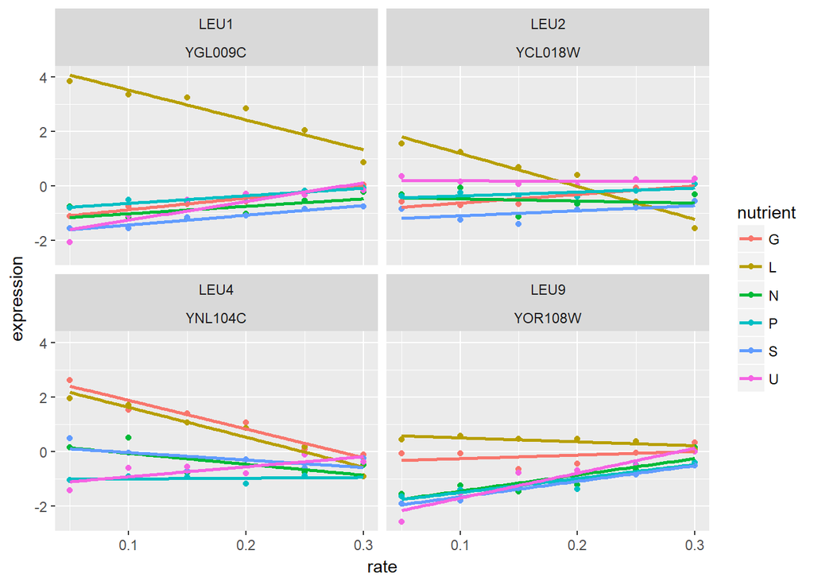

```r
url <- "http://varianceexplained.org/files/Brauer2008_DataSet1.tds"


# Clean and tidy the data
cleaned_data <- read_delim(url, delim = "\t") %>%
  separate(NAME, c("name", "BP", "MF", "systematic_name", "number"), sep = "\\|\\|") %>%
  mutate_at(vars(name:systematic_name), funs(trimws)) %>%
  select(-number, -GID, -YORF, -GWEIGHT) %>%
  gather(sample, expression, G0.05:U0.3) %>%
  separate(sample, c("nutrient", "rate"), sep = 1, convert = TRUE) %>%
  filter(!is.na(expression), systematic_name != "")

# Visualize a set of four genes
cleaned_data %>%
  filter(BP == "leucine biosynthesis") %>%
  ggplot(aes(rate, expression, color = nutrient)) +
  geom_point() +
  geom_smooth(method = "lm", se = FALSE) +
  facet_wrap(~name + systematic_name)
```

Even if you know nothing about gene expression, it should not be too difficult to understand the steps that are taken to generate a deliverable that can be used to gain understanding. The same could not necessarily be said for applying other coding styles/techniques.

This next example is adapted from a very recent RStudio webinar on the exact same topic that is discussed here–the tidyverse! [^9] It uses the famous “gapminder” data set that is seen in some of Hans Rosling TEDTalks.

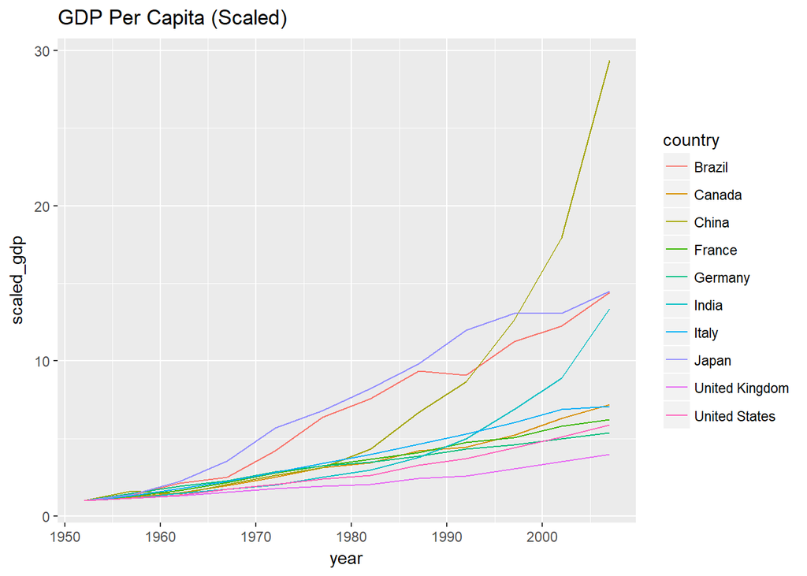

```r
library("gapminder")
top_10 <-
  gapminder %>%
  filter(year == 1952) %>%
  mutate(gdp = pop * gdpPercap) %>%
  arrange(desc(gdp)) %>%
  top_n(10, gdp) %>%
  pull(country)
# top_10


gapminder %>%
  filter(country %in% top_10) %>%
  mutate(gdp = pop * gdpPercap) %>%
  group_by(country) %>%
  mutate(scaled_gdp = gdp / first(gdp)) %>%
  ggplot() +
    geom_line(mapping = aes(x = year, y = scaled_gdp, color = country)) +
  labs(title = "GDP Per Capita (Scaled)")
```

Again, note how powerful (yet simplistic), the tidyverse can be!

[^1]: A vignette is a document that comes with a package that explains some of the functions/use cases of a package.
[^2]: Guidance for the structure and code for this section is provided by the tidyr vignette.
[^3]: For illustrative purposes, the intermediate result is stored. This does not exactly represent a “best practice”.
[^4]: Subsetting is also slightly different with tibbles.
[^5]: See [David Robinson’s breakdown](http://varianceexplained.org/r/teach-tidyverse/) of the “base R vs. tidyr” argument for more information.
[^6]: Many more helpful R “cheat sheets” can be found at https://www.rstudio.com/resources/cheatsheets/.
[^7]: This nycflights13 code is borrowed from the dplyr vignette.
[^8]: This article discusses the “base R vs. tidyr” argument in regards to how to teach beginners. He makes a strong case in favor of tidyr principles, or, at the least, not avoiding it completely.
[^9]: See https://github.com/rstudio/webinars/tree/master/46-tidyverse-visualisation-and-manipulation-basics to download the materials. Also, see https://www.rstudio.com/resources/webinars/ for RStudio’s webinars.